# Changepoint Detection in Financial Time Series

25 April, 2018

## About

Change points are abrupt variations in time series data. Such abrupt changes may represent transitions that occur between states. Detection of change points is useful in modelling and prediction of time series and is found in application areas such as medical condition monitoring, climate change detection, speech and image analysis, and human activity analysis.

## Methodology

Changepoint detection is the name given to the problem of estimating the point(s) at which the statistical properties of a time-series observations change. In this project, I focus on the changes in mean and variance. The penalty function is chosen as SIC (Schwarz Information Criterion); and we employ the PELT (Pruned Exact Linear Time) searching algorithm for the change points proposed by Killick et al. (2012).

## Changepoint Detections for Brent Crude Oil

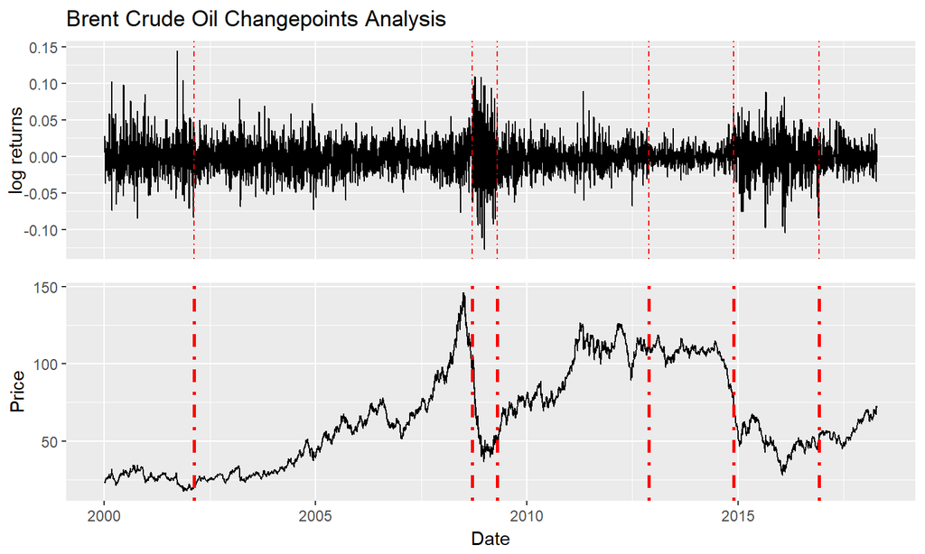

## Events Brent Crude Oil Changepoint

```
## # A tibble: 6 x 2
##   Date                News
##   <dttm>              <chr>
## 1 2002-02-13 00:00:00 JetBlues files plans for 125 million offering
## 2 2008-09-15 00:00:00 Financial Crisis 08
## 3 2009-04-21 00:00:00 Smart Money Moves for Young Investors
## 4 2012-11-21 00:00:00 A preliminary gauge of China's manufacturing activi~
## 5 2014-11-27 00:00:00 Oil Seen in New Era as OPEC Won’t Yield to U.S. Sha~
## 6 2016-12-02 00:00:00 America’s Job Market Gets Tighter, as Wage Drop See~
```

## All Changepoints

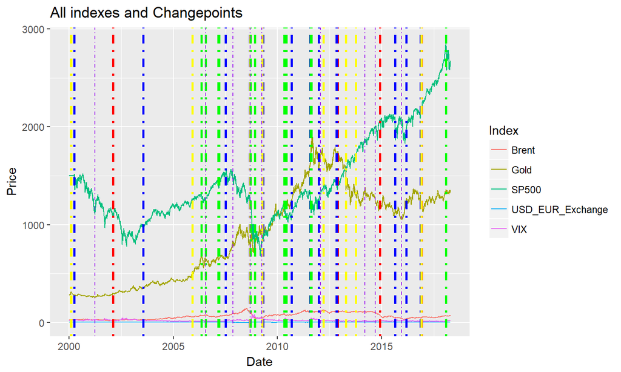

## Observation 1

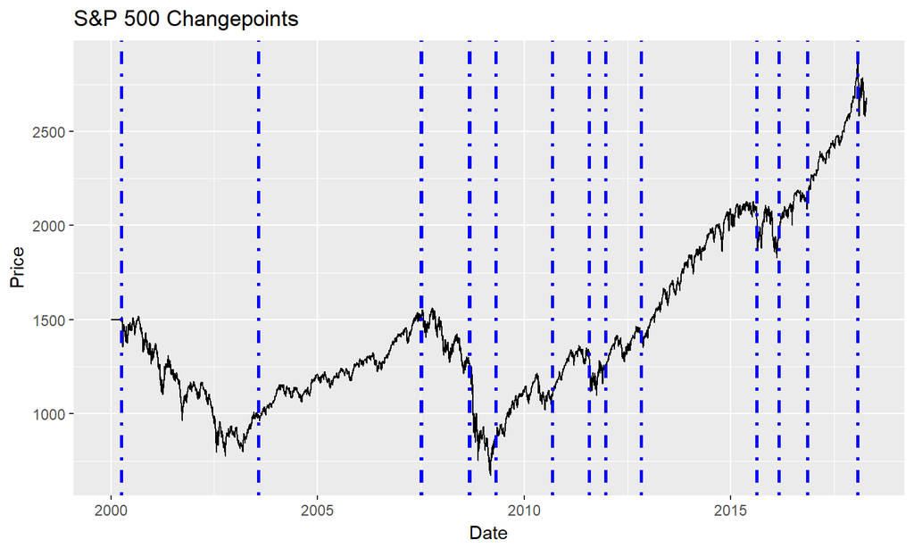

Stock Price seems to have more frequent structural Changepoints

## Observation 2

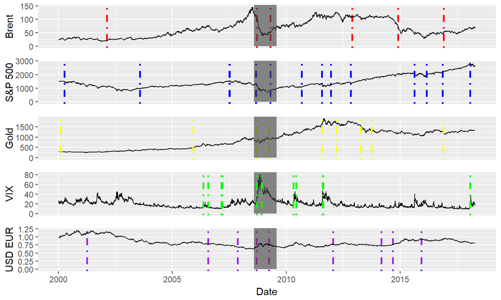

## Observations 3

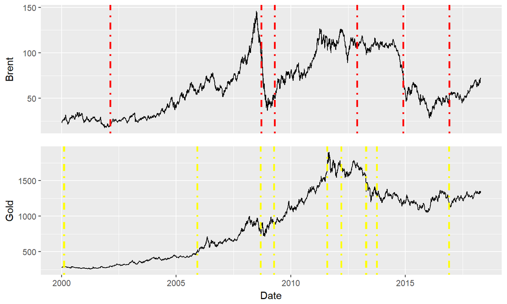

## Observations 4

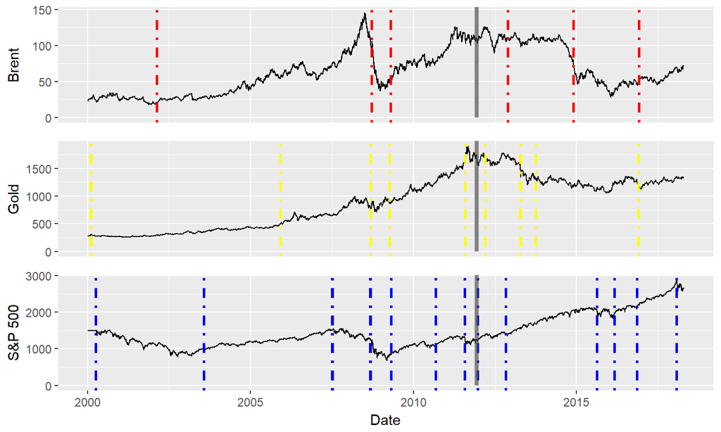

## Implications

In conclusion, this study shows that Indexes can be partition in various segments/periods. This model shows the potential of continous monitoring of indexes to be able to detect changepoint(segmentation points) as time goes on.